# Airbnb data analysis

November 7, 2020

Authors:

RAZAFINDRAZAKA Henintsoa

WANG James

# Data Preprocessing

For the preprocessing, we use the preprocessing script. We run this script with source().

```r
source("data_preparation_script.R", local = knitr::knit_global())
```

```
## [1] "reading data from malaga/listings.csv.gz"
## [1] "reading data from malaga/calendar.csv.gz"
## [1] "saving data into data_cleansed/malaga/2020-06-30/listings.csv"
## [1] "-------------------------------------------------"
## [1] "Preparing data for malaga compiled at 2020-06-30"
## [1] "reading data from malaga/listings.csv.gz"
## [1] "reading data from malaga/calendar.csv.gz"
## [1] "saving data into data_cleansed/malaga/2020-06-30/listings.csv"
## [1] "-------------------------------------------------"
## [1] "Preparing data for mallorca compiled at 2020-09-19"
## [1] "reading data from mallorca/listings.csv.gz"
## [1] "reading data from mallorca/calendar.csv.gz"
## [1] "saving data into data_cleansed/mallorca/2020-09-19/listings.csv"
## [1] "-------------------------------------------------"
## [1] "Preparing data for sevilla compiled at 2020-06-29"
## [1] "reading data from sevilla/listings.csv.gz"
## [1] "reading data from sevilla/calendar.csv.gz"
## [1] "saving data into data_cleansed/sevilla/2020-06-29/listings.csv"
```

let’s plot the head of listings data set :

```r
head(listings)
```

```
##     city  data_date     id neighbourhood_cleansed latitude longitude
## 1 malaga 2020-06-30  96033                   Este 36.72031  -4.35627
## 2 malaga 2020-06-30 131725     Carretera de Cadiz 36.70658  -4.43705
## 3 malaga 2020-06-30 155696                 Centro 36.72723  -4.40720
## 4 malaga 2020-06-30 159650          Ciudad Jardin 36.74604  -4.41747
## 5 malaga 2020-06-30 166473                   Este 36.71934  -4.35942
## 6 malaga 2020-06-30 212845                   Este 36.72606  -4.36541
##   property_type       room_type accommodates bedrooms beds   price
## 1     Apartment Entire home/apt            3        2    2  $49.00
## 2     Apartment Entire home/apt            3        2    3  $37.00
## 3   Condominium Entire home/apt            5        3    5 $180.00
## 4     Apartment Entire home/apt            6        3    6  $60.00
## 5     Apartment    Private room            3        1    0  $19.00
## 6     Apartment     Shared room            2        1    2  $35.00
##   minimum_nights maximum_nights availability_30 price_30 revenue_30
## 1              3           1125               3     43.0       1161
## 2              4            180               0     49.9       1497
## 3              3            365              22    180.0       1440
## 4              7             30              14     60.0        960
## 5              5            365               0     19.0        570
## 6              2             90              20     39.5        395
```

# Analysis 1

## Find the “average availability over 30 days” of listings per each city.

```r
listings %>%
  group_by(city) %>%
  summarise(average_availability_30 = mean(availability_30))
```

```
## # A tibble: 3 x 2
##   city     average_availability_30
##   <chr>                      <dbl>
## 1 malaga                      18.0
## 2 mallorca                    20.7
## 3 sevilla                     19.9
```

## Find the “average revenue of over 30 days” of listings per each city.

```r
listings %>%
  group_by(city) %>%
  summarise(Mean_revenue_30 = mean(revenue_30))
```

```
## # A tibble: 3 x 2
##   city     Mean_revenue_30
##   <chr>              <dbl>
## 1 malaga             1166.
## 2 mallorca           2159.
## 3 sevilla            1013.
```

## Comparing the distribution of estimated availability for the next 30 days of listings per each city.

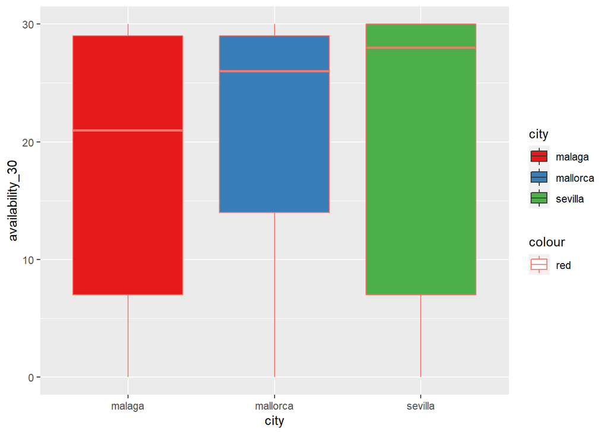

```r
avgAvai30 <- ggplot(listings, aes(city, availability_30, fill=city))
avgAvai30 + geom_boxplot(aes(colour = "red"), outlier.shape = NA) +
  scale_y_continuous(limits = quantile(listings$availability_30, c(0.1, 0.9), na.rm = T)) +
  scale_fill_brewer(palette="Set1")
```

## Comparing the distribution of estimated revenue for the next 30 days of listings per each city.

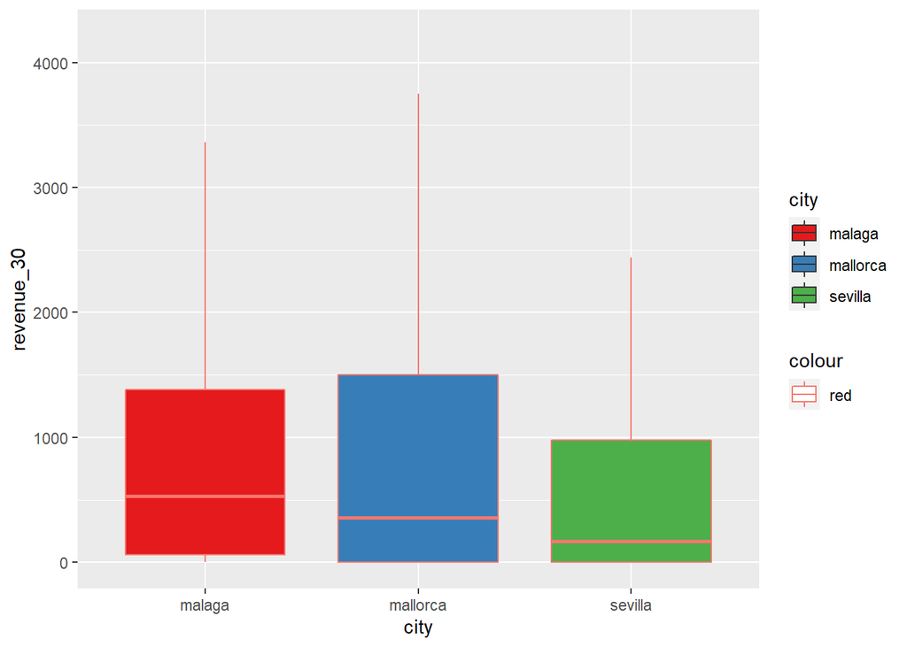

```r
avgRev30 <- ggplot(listings, aes(city, revenue_30, fill=city))
avgRev30 + geom_boxplot(aes(colour = "red"),  outlier.shape = NA) +
  scale_y_continuous(limits = quantile(listings$revenue_30, c(0.1, 0.9), na.rm = T)) +
  scale_fill_brewer(palette="Set1")
```

## Compare the distribution of estimated revenue for the next 30 days of listings per each city & for each house size (# of bedrooms).

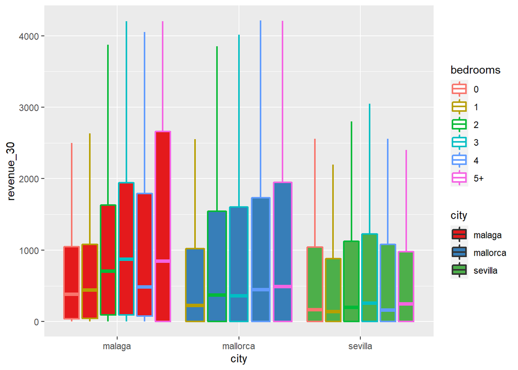

```r
avgRev30_city_bed <- ggplot(listings[!is.na(listings$bedrooms),], aes(city, revenue_30, fill=city))

avgRev30_city_bed + geom_boxplot(aes(colour = bedrooms), lwd = 0.8, position = position_dodge(0.9), outlier.shape = NA) +
  scale_y_continuous(limits = quantile(listings$revenue_30, c(0.1, 0.9), na.rm = T)) +
  scale_fill_brewer(palette="Set1")
```

## Compare the distribution of estimated revenue for the next 30 days of listings per each city & for each room type (room_type).

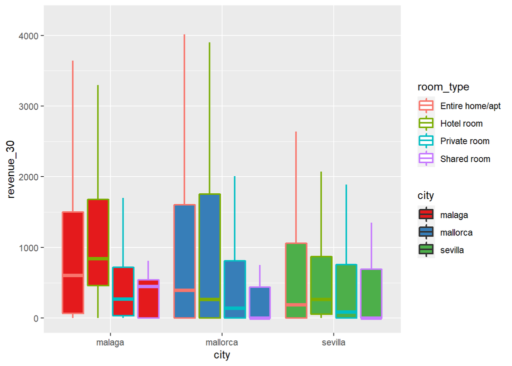

```r
avgRev30_city_roomType <- ggplot(listings, aes(city, revenue_30, fill=city))

avgRev30_city_roomType + geom_boxplot(aes(colour = room_type),  lwd = 0.8, position = position_dodge(0.9), outlier.shape = NA) +
  scale_y_continuous(limits = quantile(listings$revenue_30, c(0.1, 0.9), na.rm = T)) +
  scale_fill_brewer(palette="Set1")
```

# Analysis 2 :

## What is the proportion of each room type?

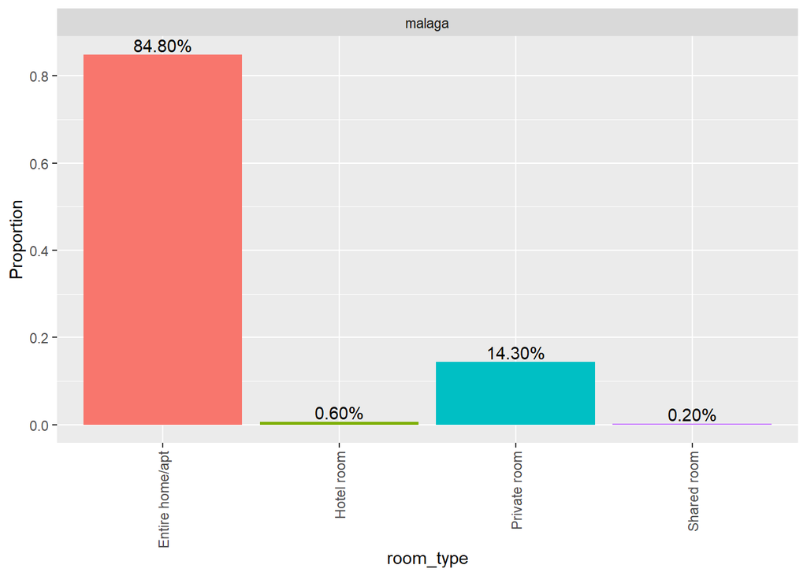

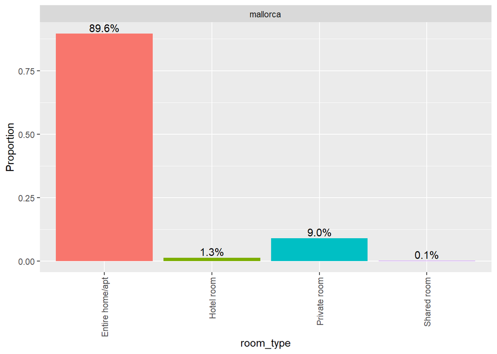

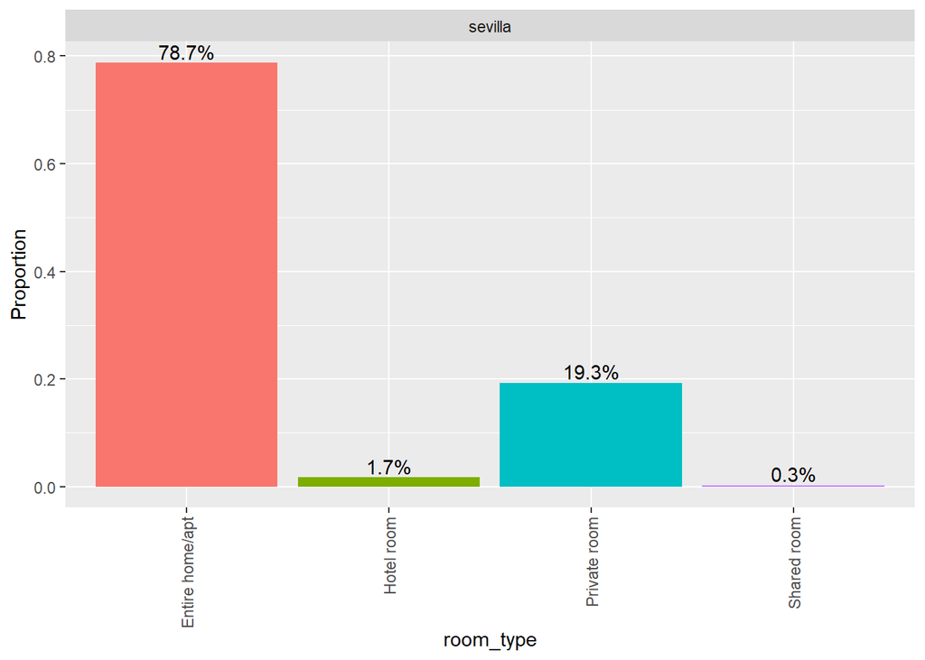

```r
for(c in cities){
    proportion_RoomType <- ggplot(listings[listings$city == c,], aes(room_type))
    g <- proportion_RoomType +
      geom_bar(aes(y = (..count..)/sum(..count..), fill=factor(..x..)), stat= "count")+
      geom_text(aes(label = scales::percent(round((..count..)/sum(..count..),3)),
                    y= ((..count..)/sum(..count..))), stat="count",
                vjust = -.25) + theme(legend.position = "none") + facet_wrap(~ city) + theme(axis.text.x = element_text(angle = 90, vjust = 0.5, hjust=1)) +
    ylab("Proportion")
    print(g)
}
```

## What is the proportion of each house size (# of bedroom)?

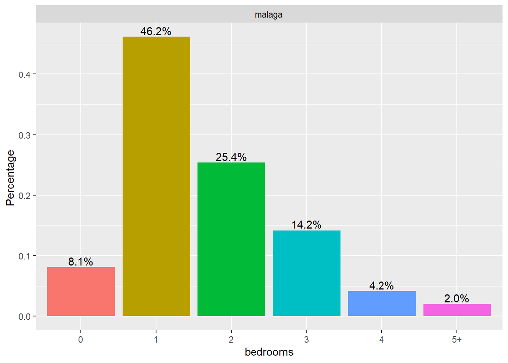

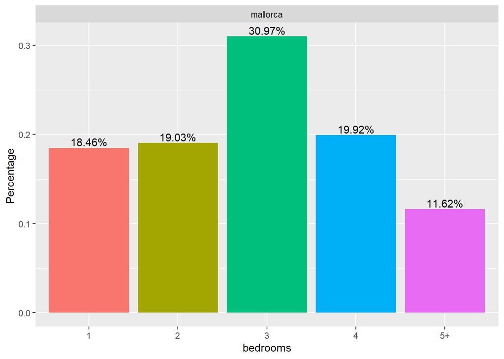

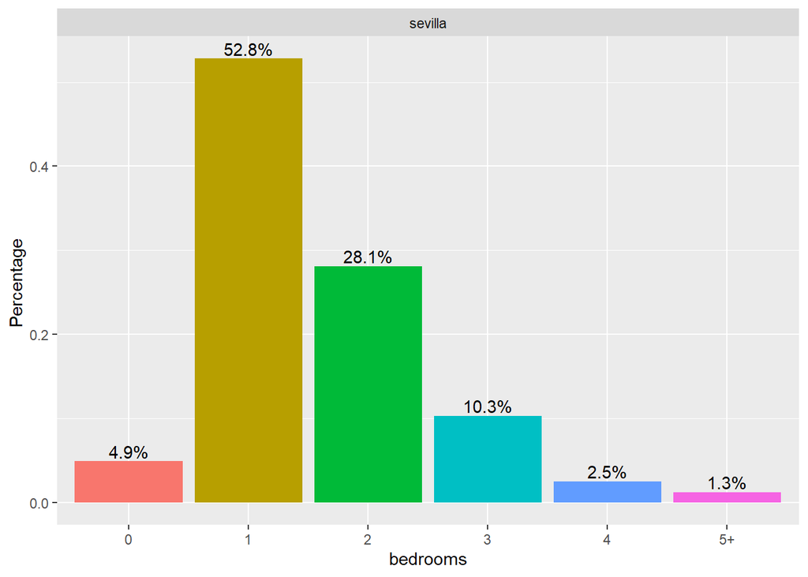

```r
for(c in cities){
  proportion_bedrooms<- ggplot(listings[listings$city == c & !is.na(listings$bedrooms), ], aes(bedrooms))
  g <- proportion_bedrooms +
    geom_bar(aes(y = (..count..)/sum(..count..), fill=factor(..x..)), stat= "count")+
    geom_text(aes(label = scales::percent(round((..count..)/sum(..count..),4)),
                  y= ((..count..)/sum(..count..))), stat="count",
              vjust = -.25) +
    ylab("Percentage ") + facet_wrap(~ city) + theme(legend.position = "none")
  print(g)
}
```

## What is the proportion of each neighborhood?

[figure not shown]

```r
proportion_neighborhood<- ggplot(listings, aes(neighbourhood_cleansed))
proportion_neighborhood +
  geom_bar(aes(y = (..count..)/sum(..count..), fill=factor(..x..)), stat= "count")+
  geom_text(aes(label = scales::percent(round((..count..)/sum(..count..),2)),
                y= ((..count..)/sum(..count..))), stat="count",
            vjust = -.25) +
  ylab("Percentage ") + theme(legend.position = "none") + coord_flip()
```

- Find the top 10 neighborhood :

```r
top_10_neighborhood <- listings %>%
  group_by(city) %>%
  count(neighbourhood_cleansed) %>%
  arrange(city, desc(n))

top_10_neighborhood
```

```
## # A tibble: 167 x 3
## # Groups:   city [3]
##    city   neighbourhood_cleansed     n
##    <chr>  <chr>                  <int>
##  1 malaga Centro                  4327
##  2 malaga Este                     643
##  3 malaga Carretera de Cadiz       539
##  4 malaga Cruz De Humilladero      287
##  5 malaga Bailen-Miraflores        165
##  6 malaga Teatinos-Universidad     101
##  7 malaga Churriana                 99
##  8 malaga Ciudad Jardin             50
##  9 malaga Palma-Palmilla            41
## 10 malaga Puerto de la Torre        31
## # ... with 157 more rows
```

- Plot top 10 neighborhood proportions :

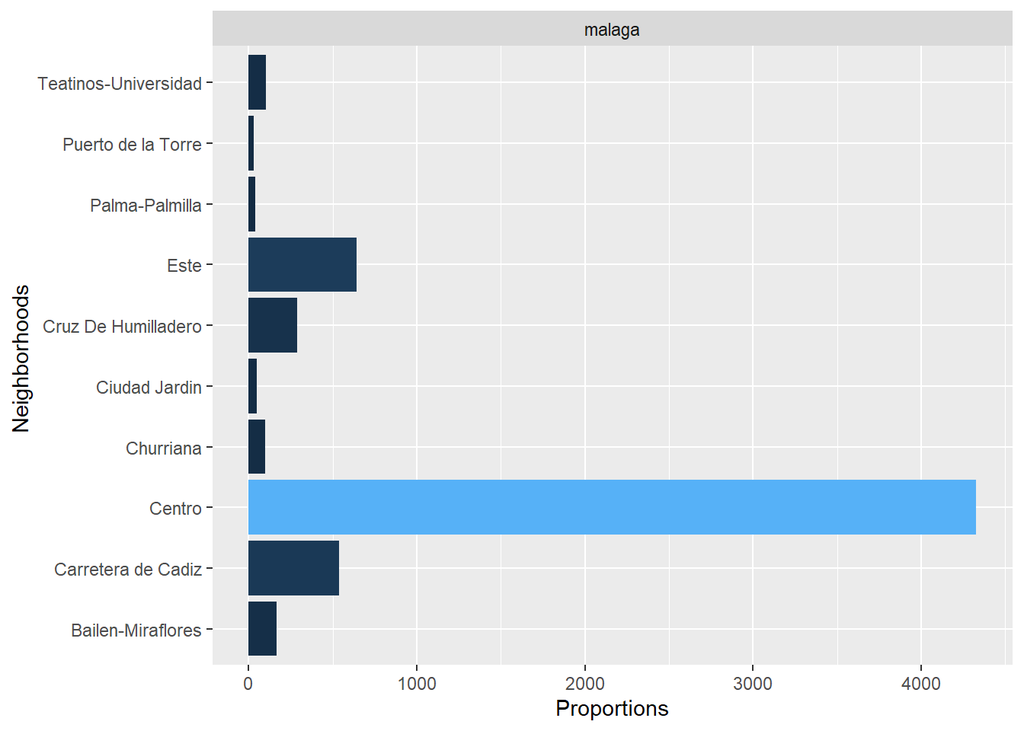

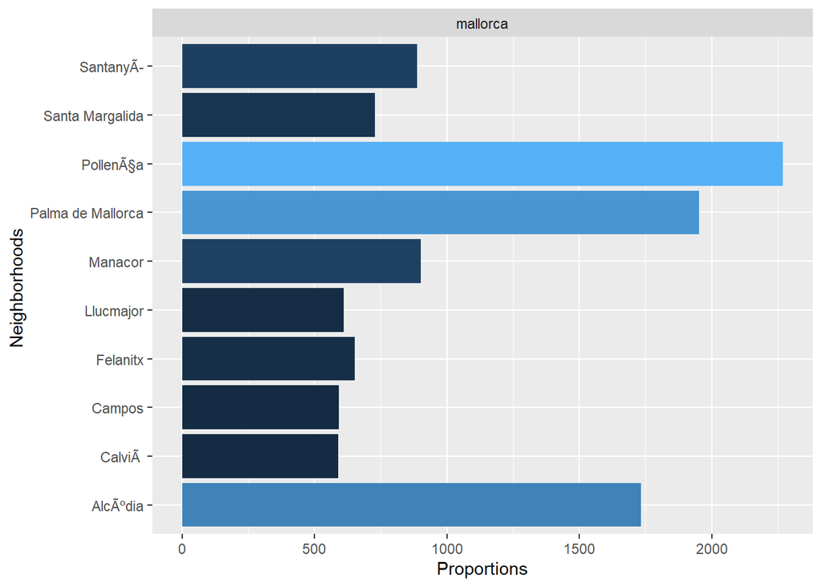

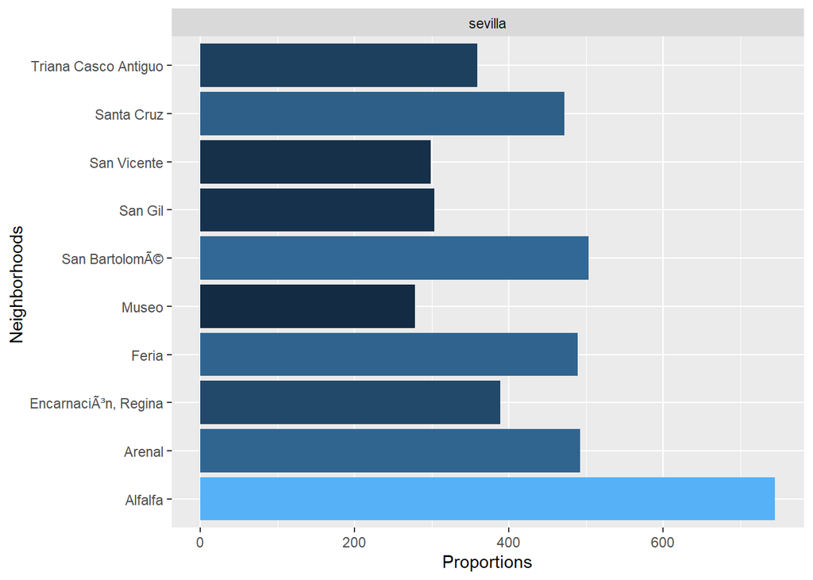

```r
for(c in cities){
  proportion_10neighborhood<- ggplot(slice(top_10_neighborhood[top_10_neighborhood$city == c,], 0:10), aes(x = reorder(neighbourhood_cleansed, -n), fill= n))

  g <- proportion_10neighborhood +
  geom_bar(aes(x = neighbourhood_cleansed, y = n), stat="identity",  lwd = 0.8, position = position_dodge(0.9), na.rm = T) +
  theme(legend.position = "none") + coord_flip() + facet_wrap(~ city) + xlab("Neighborhoods ") + ylab("Proportions")

  print(g)
}
```

## What is the average availability over the next 30 days for each room type / house size / neighborhood?

```r
for (c in cities) {
  df1 <- listings[listings$city == c,] %>%
    group_by(city, room_type) %>%
    summarise(average_availability_30 = mean(availability_30))
  print(df1)

  df2 <- listings[listings$city == c,] %>%
    group_by(city, bedrooms) %>%
    summarise(average_availability_30 = mean(availability_30))
  print(df2)

  df3 <- listings[listings$city == c,] %>%
    group_by(city, neighbourhood_cleansed) %>%
    summarise(average_availability_30 = mean(availability_30))
  print(df3)
}
```

```
## # A tibble: 4 x 3
## # Groups:   city [1]
##   city   room_type       average_availability_30
##   <chr>  <chr>                             <dbl>
## 1 malaga Entire home/apt                    18.2
## 2 malaga Hotel room                         19.0
## 3 malaga Private room                       16.6
## 4 malaga Shared room                        15.1
## # A tibble: 7 x 3
## # Groups:   city [1]
##   city   bedrooms average_availability_30
##   <chr>  <chr>                      <dbl>
## 1 malaga 0                           18.6
## 2 malaga 1                           17.8
## 3 malaga 2                           18.1
## 4 malaga 3                           17.7
## 5 malaga 4                           18.9
## 6 malaga 5+                          18.3
## 7 malaga <NA>                        20.3
## # A tibble: 11 x 3
## # Groups:   city [1]
##    city   neighbourhood_cleansed average_availability_30
##    <chr>  <chr>                                    <dbl>
##  1 malaga Bailen-Miraflores                         16.6
##  2 malaga Campanillas                               11.3
##  3 malaga Carretera de Cadiz                        16.1
##  4 malaga Centro                                    18.7
##  5 malaga Churriana                                 16.7
##  6 malaga Ciudad Jardin                             13.2
##  7 malaga Cruz De Humilladero                       19.2
##  8 malaga Este                                      15.4
##  9 malaga Palma-Palmilla                            15.8
## 10 malaga Puerto de la Torre                        14.9
## 11 malaga Teatinos-Universidad                      20.0
## # A tibble: 4 x 3
## # Groups:   city [1]
##   city     room_type       average_availability_30
##   <chr>    <chr>                             <dbl>
## 1 mallorca Entire home/apt                    20.8
## 2 mallorca Hotel room                         17.0
```

[output cut: 46 more lines]

```
## # A tibble: 103 x 3
## # Groups:   city [1]
##    city    neighbourhood_cleansed average_availability_30
##    <chr>   <chr>                                    <dbl>
##  1 sevilla Aeropuerto Viejo                          30
##  2 sevilla Alfalfa                                   20.3
##  3 sevilla Amate                                     23.4
##  4 sevilla an Roque                                  15.8
##  5 sevilla Arbol Gordo                               15
##  6 sevilla Arenal                                    20.6
##  7 sevilla Avda. de la Paz                           22.8
##  8 sevilla Bami                                      22.5
##  9 sevilla Barrio LeÃ³n                              19.3
## 10 sevilla Bda. de Pineda                             7
## # ... with 93 more rows
```

## What is the average revenue over the next 30 days for each room type / house size / neighborhood?

```r
for (c in cities) {
  df1 <- listings[listings$city == c,] %>%
    group_by(city, room_type) %>%
    summarise(average_revenue_30 = mean(revenue_30))
  print(df1)

  df2 <- listings[listings$city == c,] %>%
    group_by(city, bedrooms) %>%
    summarise(average_revenue_30 = mean(revenue_30))
  print(df2)

  df3 <- listings[listings$city == c,] %>%
    group_by(city, neighbourhood_cleansed) %>%
    summarise(average_revenue_30 = mean(revenue_30))
  print(df3)
}
```

```
## # A tibble: 4 x 3
## # Groups:   city [1]
##   city   room_type       average_revenue_30
##   <chr>  <chr>                        <dbl>
## 1 malaga Entire home/apt              1280.
## 2 malaga Hotel room                   1180.
## 3 malaga Private room                  500.
## 4 malaga Shared room                   465.
## # A tibble: 7 x 3
## # Groups:   city [1]
##   city   bedrooms average_revenue_30
##   <chr>  <chr>                 <dbl>
## 1 malaga 0                      815.
## 2 malaga 1                      851.
## 3 malaga 2                     1342.
## 4 malaga 3                     1468.
## 5 malaga 4                     1869.
## 6 malaga 5+                    4056.
## 7 malaga <NA>                   277.
## # A tibble: 11 x 3
## # Groups:   city [1]
##    city   neighbourhood_cleansed average_revenue_30
##    <chr>  <chr>                               <dbl>
##  1 malaga Bailen-Miraflores                    720.
##  2 malaga Campanillas                         2396.
##  3 malaga Carretera de Cadiz                  1163.
##  4 malaga Centro                              1092.
##  5 malaga Churriana                           2127.
##  6 malaga Ciudad Jardin                       1335.
##  7 malaga Cruz De Humilladero                  668.
##  8 malaga Este                                1780.
##  9 malaga Palma-Palmilla                      1631.
## 10 malaga Puerto de la Torre                  2176.
## 11 malaga Teatinos-Universidad                 827.
## # A tibble: 4 x 3
## # Groups:   city [1]
##   city     room_type       average_revenue_30
##   <chr>    <chr>                        <dbl>
## 1 mallorca Entire home/apt              2266.
## 2 mallorca Hotel room                   4085.
```

[output cut: 46 more lines]

```
## # A tibble: 103 x 3
## # Groups:   city [1]
##    city    neighbourhood_cleansed average_revenue_30
##    <chr>   <chr>                               <dbl>
##  1 sevilla Aeropuerto Viejo                       0
##  2 sevilla Alfalfa                              973.
##  3 sevilla Amate                                203
##  4 sevilla an Roque                             989.
##  5 sevilla Arbol Gordo                         2250
##  6 sevilla Arenal                              1032.
##  7 sevilla Avda. de la Paz                      201.
##  8 sevilla Bami                                 630.
##  9 sevilla Barrio LeÃ³n                         353.
## 10 sevilla Bda. de Pineda                      1334
## # ... with 93 more rows
```

## What is the distribution of availability over the next 30 days for each room type / house size / neighborhood?

- distribution of availability for the next 30 days per each city and room type

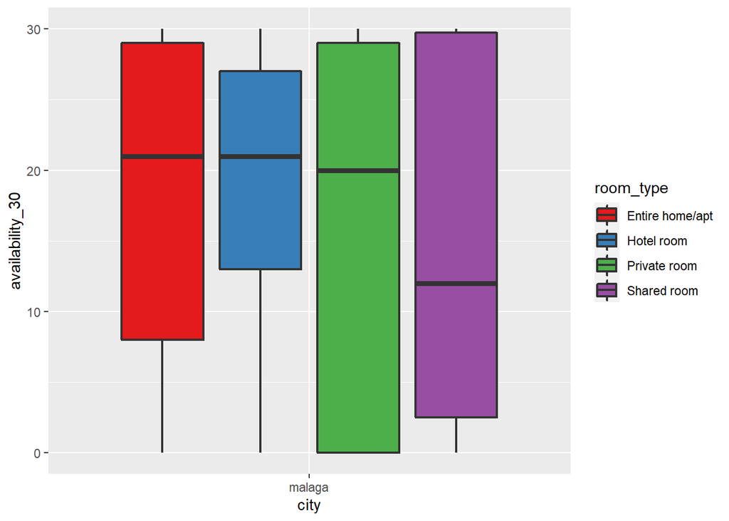

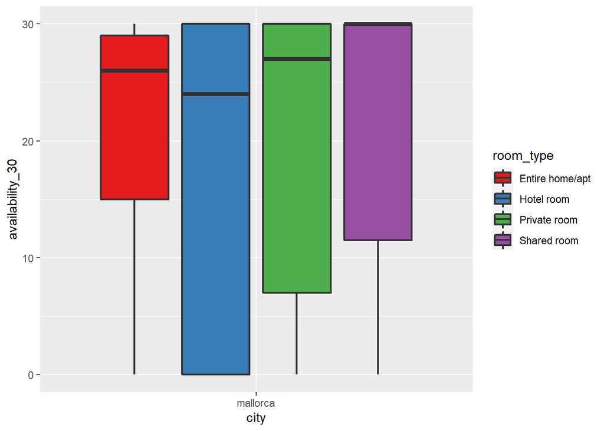

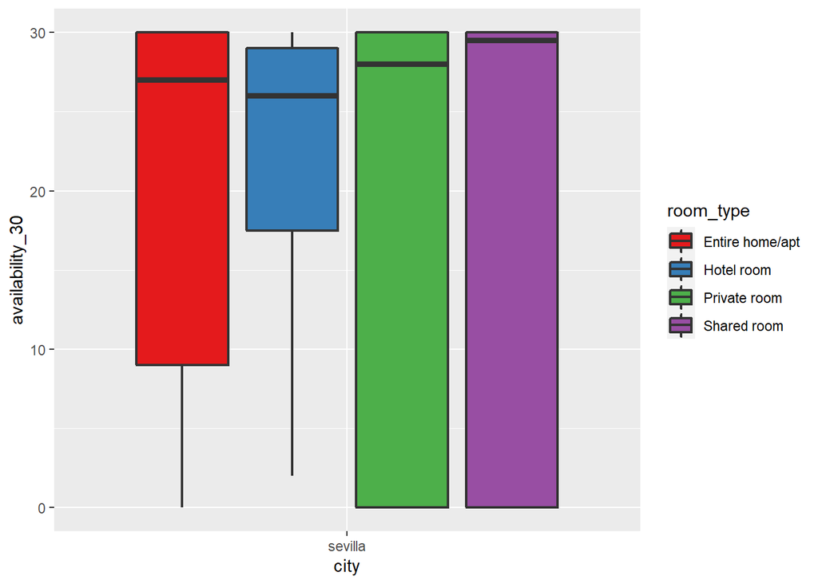

```r
for (c in cities) {
  Avai30_city_roomType <- ggplot(listings[listings$city == c,], aes(city, availability_30, fill=room_type))

  g <- Avai30_city_roomType + geom_boxplot(lwd = 0.8, position = position_dodge(0.9), outlier.shape = NA) +
    scale_y_continuous(limits = quantile(listings$availability_30, c(0.1, 0.9), na.rm = T)) +
    scale_fill_brewer(palette="Set1")

  print(g)
}
```

- distribution of availability for the next 30 days per each city and house size

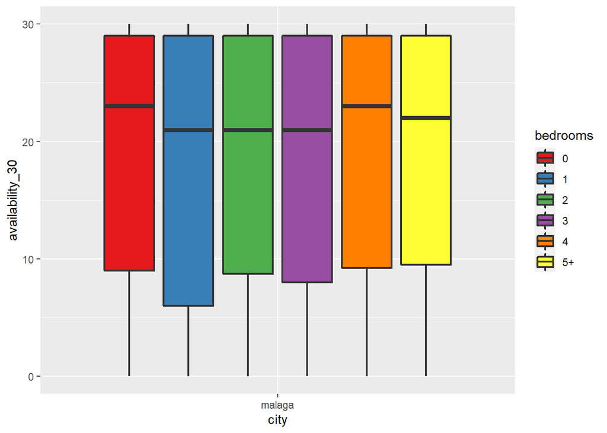

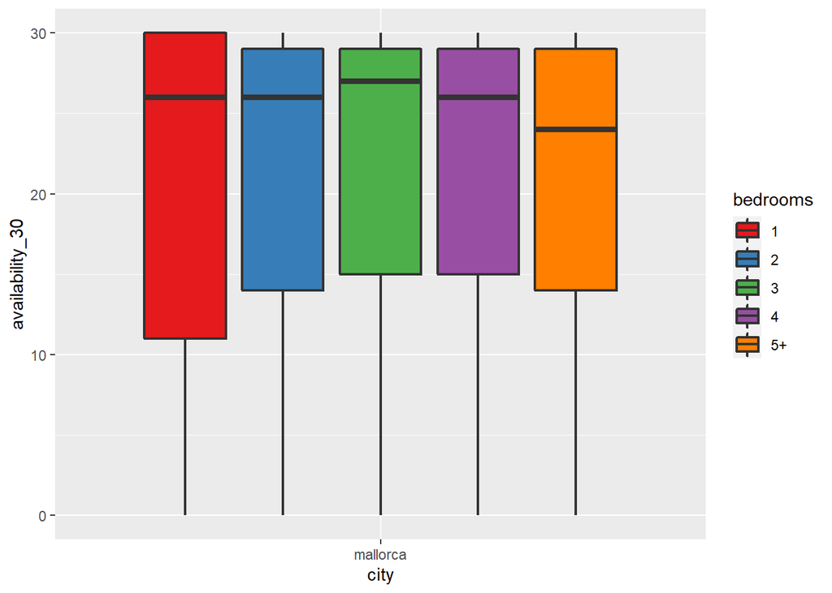

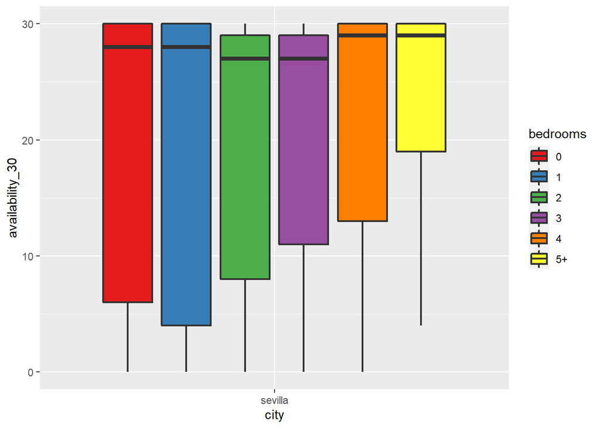

```r
for (c in cities) {
  Avai30_city_bedrooms <- ggplot(listings[listings$city == c & !is.na(listings$bedrooms), ], aes(city, availability_30, fill=bedrooms))

  g <- Avai30_city_bedrooms + geom_boxplot(lwd = 0.8, position = position_dodge(0.9), outlier.shape = NA) +
    scale_y_continuous(limits = quantile(listings$availability_30, c(0.1, 0.9), na.rm = T)) +
    scale_fill_brewer(palette="Set1")

  print(g)
}
```

- distribution of availability for the next 30 days per each city and neighborhood

```r
Availability30_top_10_neighborhood <- listings %>%
  group_by(city, neighbourhood_cleansed) %>%
  summarise(sum_avai30 = sum(availability_30)) %>%
  top_n(10)
  #arrange(city, desc(sum_avai30))

Availability30_top_10_neighborhood
```

```
## # A tibble: 30 x 3
## # Groups:   city [3]
##    city   neighbourhood_cleansed sum_avai30
##    <chr>  <chr>                       <int>
##  1 malaga Bailen-Miraflores            2734
##  2 malaga Carretera de Cadiz           8668
##  3 malaga Centro                      80705
##  4 malaga Churriana                    1655
##  5 malaga Ciudad Jardin                 658
##  6 malaga Cruz De Humilladero          5524
##  7 malaga Este                         9901
##  8 malaga Palma-Palmilla                649
##  9 malaga Puerto de la Torre            463
## 10 malaga Teatinos-Universidad         2023
## # ... with 20 more rows
```

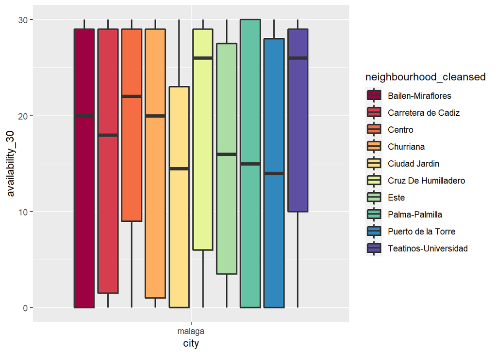

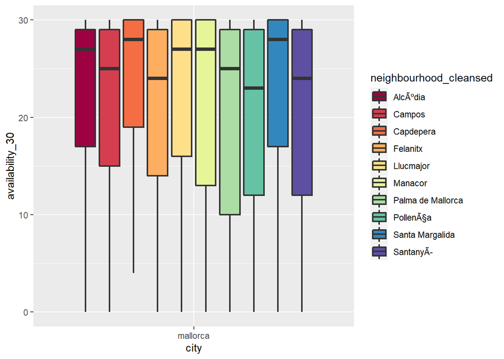

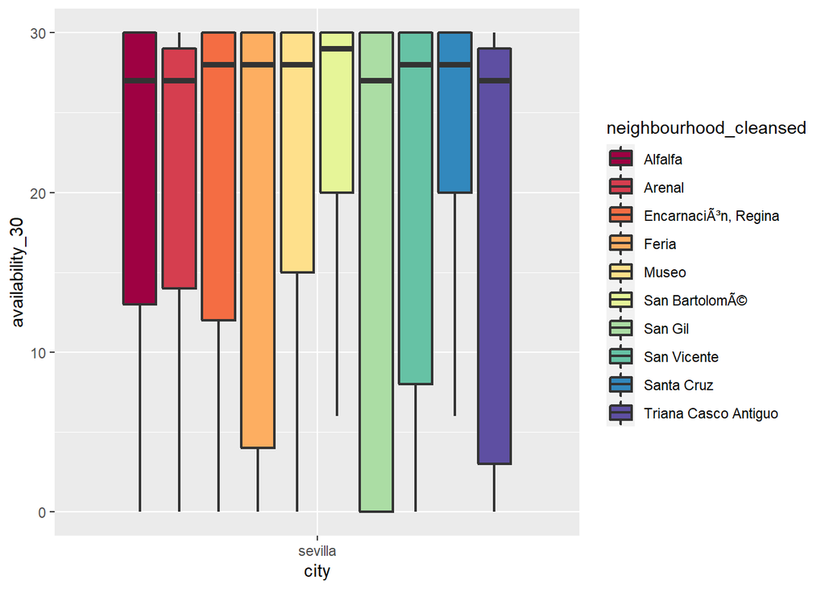

```r
for(c in cities){
  Avai30_city_neighbourhood_cleansed <- ggplot(listings[listings$city == c & listings$neighbourhood_cleansed %in% Availability30_top_10_neighborhood$neighbourhood_cleansed,], aes(city, availability_30, fill=neighbourhood_cleansed))

  g <- Avai30_city_neighbourhood_cleansed +
  geom_boxplot(lwd = 0.8, position = position_dodge(0.9), outlier.shape = NA) +
  scale_y_continuous(limits = quantile(listings$availability_30, c(0.1, 0.9), na.rm = T)) +
  scale_fill_brewer(palette="Spectral")

  print(g)
}
```

## What is the distribution of revenue over the next 30 days for each room type / house size / neighborhood?

- distribution of revenue over the next 30 days for each room type and each city

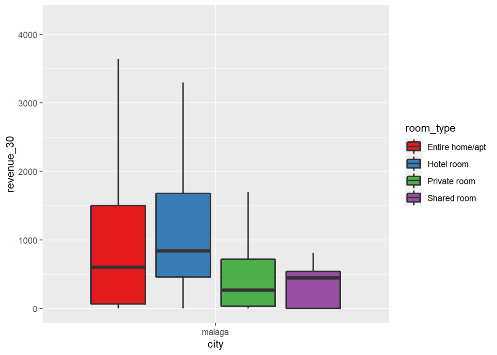

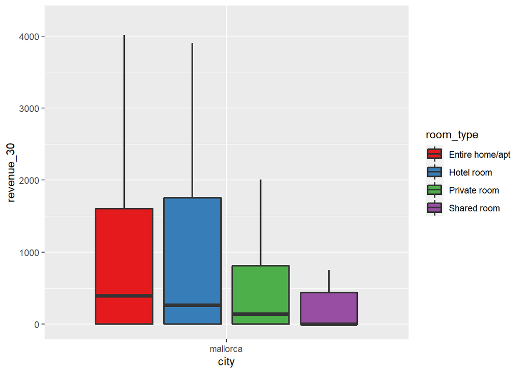

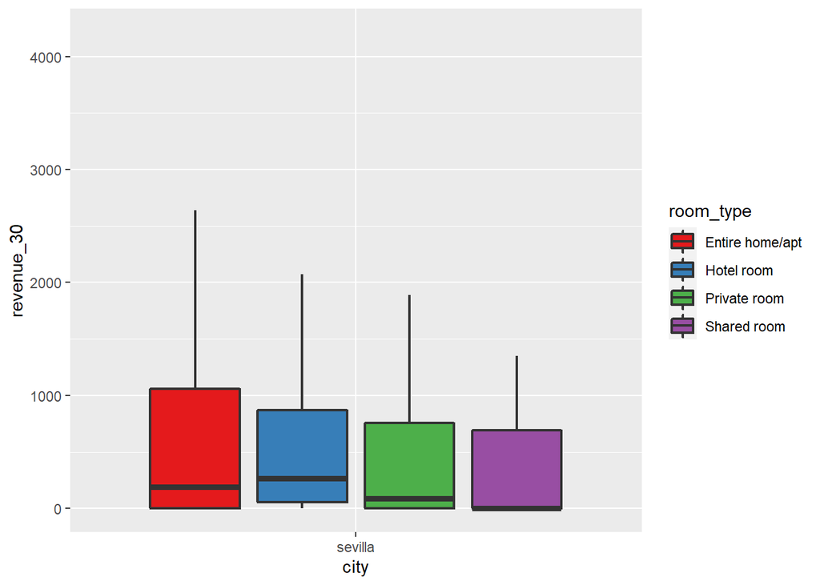

```r
for (c in cities) {
  Rev30_city_roomType <- ggplot(listings[listings$city == c,], aes(city, revenue_30, fill=room_type))

  g <- Rev30_city_roomType + geom_boxplot(lwd = 0.8, position = position_dodge(0.9), outlier.shape = NA) +
    scale_y_continuous(limits = quantile(listings$revenue_30, c(0.1, 0.9), na.rm = T)) +
    scale_fill_brewer(palette="Set1")

  print(g)
}
```

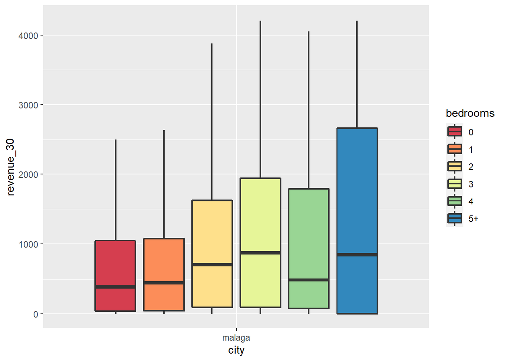

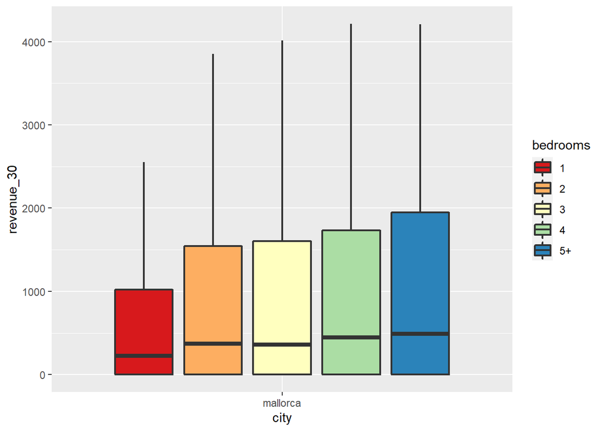

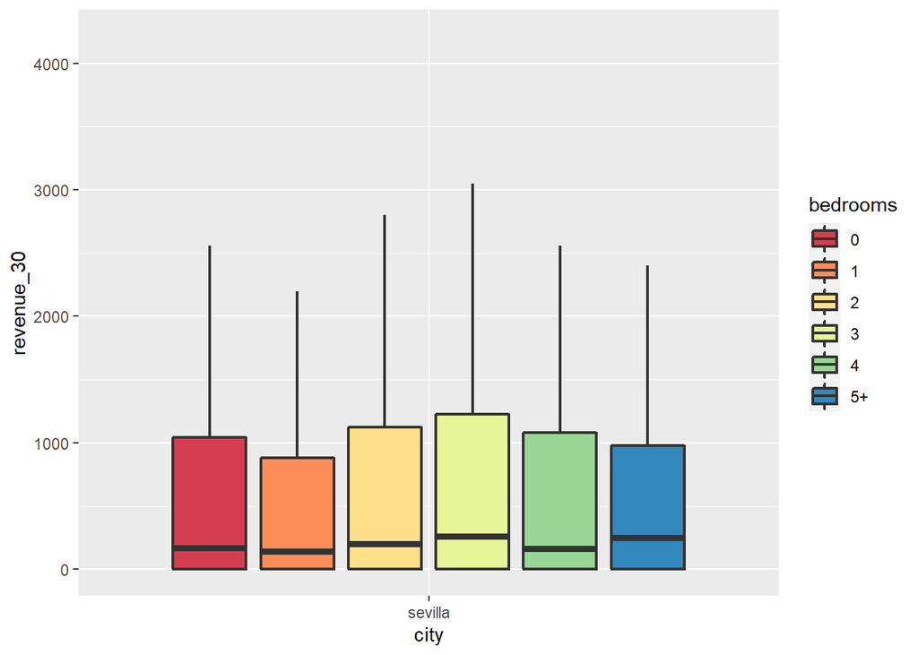

```r
for (c in cities) {
  Rev30_city_bedrooms <- ggplot(listings[listings$city == c & !is.na(listings$bedrooms), ], aes(city, revenue_30, fill=bedrooms))

  g <- Rev30_city_bedrooms + geom_boxplot(lwd = 0.8, position = position_dodge(0.9), outlier.shape = NA) +
    scale_y_continuous(limits = quantile(listings$revenue_30, c(0.1, 0.9), na.rm = T)) +
    scale_fill_brewer(palette="Spectral")

  print(g)
}
```

- distribution of revenue over the next 30 days for each neighborhood and each city

```r
Revenue30_top_10_neighborhood <- listings %>%
  group_by(city, neighbourhood_cleansed) %>%
  summarise(sum_revenue30 = sum(revenue_30)) %>%
  top_n(10)

Revenue30_top_10_neighborhood
```

```
## # A tibble: 30 x 3
## # Groups:   city [3]
##    city   neighbourhood_cleansed sum_revenue30
##    <chr>  <chr>                          <dbl>
##  1 malaga Bailen-Miraflores             118879
##  2 malaga Carretera de Cadiz            626730
##  3 malaga Centro                       4725473
##  4 malaga Churriana                     210566
##  5 malaga Ciudad Jardin                  66730
##  6 malaga Cruz De Humilladero           191613
##  7 malaga Este                         1144821
##  8 malaga Palma-Palmilla                 66885
##  9 malaga Puerto de la Torre             67446
## 10 malaga Teatinos-Universidad           83514
## # ... with 20 more rows
```

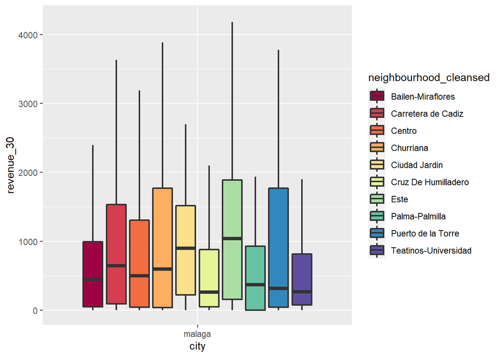

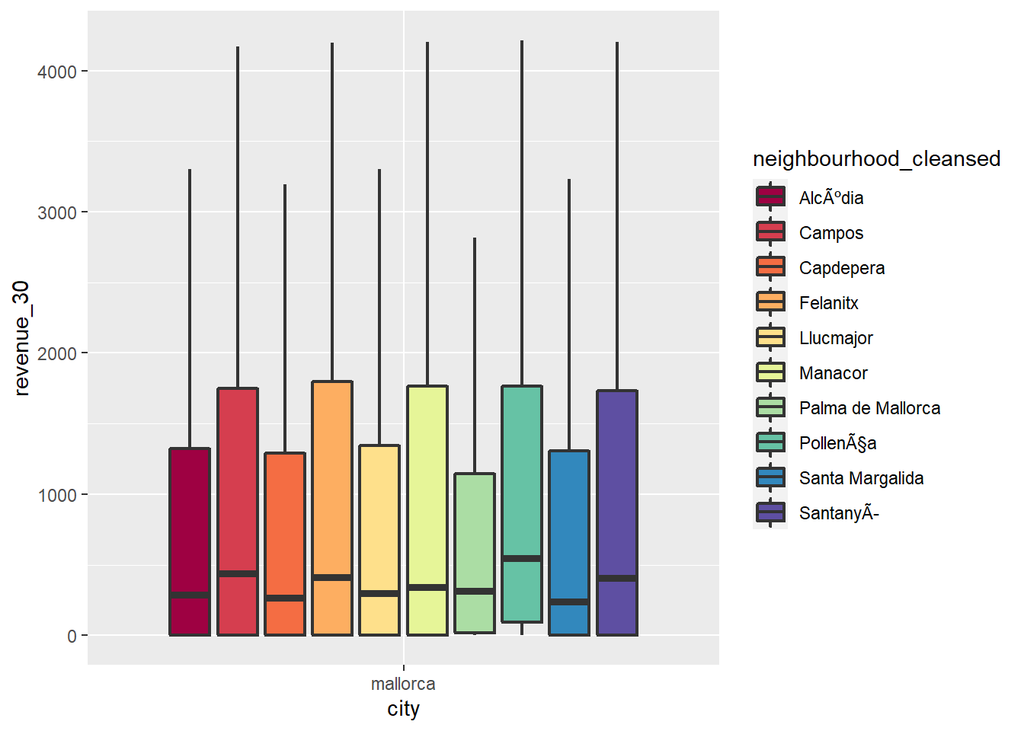

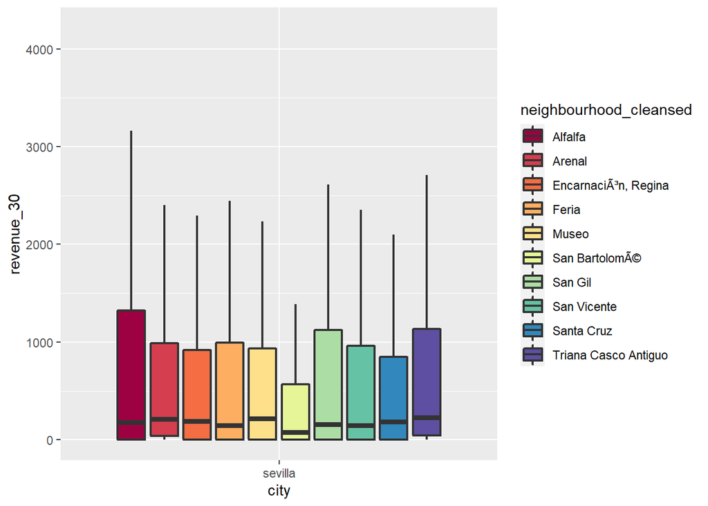

```r
for(c in cities){
  Rev30_city_neighbourhood_cleansed <- ggplot(listings[listings$city == c & listings$neighbourhood_cleansed %in% Availability30_top_10_neighborhood$neighbourhood_cleansed,], aes(city, revenue_30, fill=neighbourhood_cleansed))

  g <- Rev30_city_neighbourhood_cleansed +
  geom_boxplot(lwd = 0.8, position = position_dodge(0.9), outlier.shape = NA) +
  scale_y_continuous(limits = quantile(listings$revenue_30, c(0.1, 0.9), na.rm = T)) +
  scale_fill_brewer(palette="Spectral")

  print(g)
}
```